# HT switch analysis: T_HT and H_HT

Author

Project

Published

August 6, 2026

## 1 Scope

This report focuses on the HT reference transcriptome datasets:

- `T_HT` (anchor)
- `H_HT` (supplementary)

Ranking is performed with q-value cutoffs, ordered by `max_abs_dif_switching`, and flags genes with two or more significant isoforms that switch in opposing directions.

```r
library(knitr)
library(dplyr)

source("_setup.R")
fig <- make_fig("ht_top_switch_plots")
```

```r
cat(reduction_caveat())
```

**ImportantInputs are already reduced to switching genes**

All 4 of 4 input ISA objects contain **only genes that already pass the gene-level q cutoff** (saved after `isoformSwitchTestDEXSeq(reduceToSwitchingGenes = TRUE)`).

Consequences for everything below: gene counts are *genes retained*, not *genes tested*; “present in the other dataset” means *retained in that saved object*, not *tested and non-significant*; and any percentage of genes has a denominator that was already selected on the outcome. Overlap between datasets is bounded by how many symbols survive in both objects. No enrichment test against this background is reported. See `docs/REVIEW_CHANGES.md`.

```r
require_outputs(
  c(
    "top_switching_genes_T_HT_anchor.csv",
    "top_switching_genes_H_HT_supplementary.csv",
    "isoform_overlap_T_HT_vs_H_HT_summary.csv",
    "isoform_overlap_T_significant_in_H_context.csv"
  ),
  "Missing HT analysis outputs. Run: Rscript scripts/06_visualization.R"
)
```

```
                                                                            top_switching_genes_T_HT_anchor.csv
           "/Users/samkatz/projects/isoform-switch-pipeline/results/tables/top_switching_genes_T_HT_anchor.csv"
                                                                     top_switching_genes_H_HT_supplementary.csv
    "/Users/samkatz/projects/isoform-switch-pipeline/results/tables/top_switching_genes_H_HT_supplementary.csv"
                                                                       isoform_overlap_T_HT_vs_H_HT_summary.csv
      "/Users/samkatz/projects/isoform-switch-pipeline/results/tables/isoform_overlap_T_HT_vs_H_HT_summary.csv"
                                                                 isoform_overlap_T_significant_in_H_context.csv
"/Users/samkatz/projects/isoform-switch-pipeline/results/tables/isoform_overlap_T_significant_in_H_context.csv"
```

```r
t_top <- read_tab("top_switching_genes_T_HT_anchor.csv")
h_top <- read_tab("top_switching_genes_H_HT_supplementary.csv")
ov_sum <- read_tab("isoform_overlap_T_HT_vs_H_HT_summary.csv")
ov_detail <- read_tab("isoform_overlap_T_significant_in_H_context.csv")
```

## 2 T_HT panel

### 2.1 Top 30 genes (ranked by max_abs_dif_switching)

```r
knitr::kable(
  t_top,
  digits = 4,
  caption = "T_HT top 30 genes (q-cutoff filtered; ranked by max_abs_dif_switching)"
)
```

T_HT top 30 genes (q-cutoff filtered; ranked by max_abs_dif_switching)

| gene_id | gene_name | n_isoforms | n_switching_isoforms | n_switching_up | n_switching_down | max_abs_dif_switching | min_isoform_switch_q | min_gene_switch_q | has_opposing_direction_switches | has_multi_isoform_opposing_switch | rank | dataset_key | dataset_label | isoform_q_cutoff | gene_q_cutoff | min_abs_dif_cutoff |
| --- | --- | --- | --- | --- | --- | --- | --- | --- | --- | --- | --- | --- | --- | --- | --- | --- |
| XLOC_045300 | NCOA7 | 14 | 3 | 1 | 2 | 0.6522 | 0.0000 | 0.0000 | TRUE | TRUE | 1 | T_HT | T_HT_anchor | 0.05 | 0.05 | 0.15 |
| XLOC_030370 | RBKS | 5 | 2 | 1 | 1 | 0.4654 | 0.0000 | 0.0000 | TRUE | TRUE | 2 | T_HT | T_HT_anchor | 0.05 | 0.05 | 0.15 |
| XLOC_028123 | RSAD2 | 21 | 3 | 1 | 2 | 0.3671 | 0.0000 | 0.0000 | TRUE | TRUE | 3 | T_HT | T_HT_anchor | 0.05 | 0.05 | 0.15 |
| XLOC_031873 | MREG | 7 | 2 | 1 | 1 | 0.3184 | 0.0000 | 0.0000 | TRUE | TRUE | 4 | T_HT | T_HT_anchor | 0.05 | 0.05 | 0.15 |
| XLOC_021587 | KDM6B | 4 | 2 | 1 | 1 | 0.3041 | 0.0059 | 0.0059 | TRUE | TRUE | 5 | T_HT | T_HT_anchor | 0.05 | 0.05 | 0.15 |
| XLOC_046969 | IPCEF1 | 22 | 5 | 3 | 2 | 0.2900 | 0.0000 | 0.0000 | TRUE | TRUE | 6 | T_HT | T_HT_anchor | 0.05 | 0.05 | 0.15 |
| XLOC_053671 | DDX58 | 41 | 3 | 1 | 2 | 0.2820 | 0.0000 | 0.0000 | TRUE | TRUE | 7 | T_HT | T_HT_anchor | 0.05 | 0.05 | 0.15 |
| XLOC_005992 | IFIT1 | 18 | 2 | 1 | 1 | 0.2691 | 0.0000 | 0.0000 | TRUE | TRUE | 8 | T_HT | T_HT_anchor | 0.05 | 0.05 | 0.15 |
| XLOC_011323 | IL23A | 4 | 2 | 1 | 1 | 0.2664 | 0.0000 | 0.0000 | TRUE | TRUE | 9 | T_HT | T_HT_anchor | 0.05 | 0.05 | 0.15 |
| XLOC_015708 | RIN3 | 11 | 2 | 1 | 1 | 0.2494 | 0.0054 | 0.0014 | TRUE | TRUE | 10 | T_HT | T_HT_anchor | 0.05 | 0.05 | 0.15 |
| XLOC_044803 | TMEM63B | 6 | 2 | 1 | 1 | 0.2477 | 0.0000 | 0.0000 | TRUE | TRUE | 11 | T_HT | T_HT_anchor | 0.05 | 0.05 | 0.15 |
| XLOC_023406 | CCL3 | 17 | 2 | 1 | 1 | 0.2347 | 0.0000 | 0.0000 | TRUE | TRUE | 12 | T_HT | T_HT_anchor | 0.05 | 0.05 | 0.15 |
| XLOC_023106 | PLD6 | 11 | 2 | 1 | 1 | 0.2215 | 0.0000 | 0.0000 | TRUE | TRUE | 13 | T_HT | T_HT_anchor | 0.05 | 0.05 | 0.15 |
| XLOC_022554 | PITPNC1 | 6 | 2 | 1 | 1 | 0.2212 | 0.0001 | 0.0001 | TRUE | TRUE | 14 | T_HT | T_HT_anchor | 0.05 | 0.05 | 0.15 |
| XLOC_015588 | JDP2 | 8 | 2 | 1 | 1 | 0.2092 | 0.0000 | 0.0000 | TRUE | TRUE | 15 | T_HT | T_HT_anchor | 0.05 | 0.05 | 0.15 |
| XLOC_032186 | ATRN | 3 | 2 | 1 | 1 | 0.2079 | 0.0013 | 0.0013 | TRUE | TRUE | 16 | T_HT | T_HT_anchor | 0.05 | 0.05 | 0.15 |
| XLOC_044269 | TMEM170B | 2 | 2 | 1 | 1 | 0.1927 | 0.0083 | 0.0083 | TRUE | TRUE | 17 | T_HT | T_HT_anchor | 0.05 | 0.05 | 0.15 |
| XLOC_022044 | CCL4 | 20 | 2 | 1 | 1 | 0.1885 | 0.0129 | 0.0129 | TRUE | TRUE | 18 | T_HT | T_HT_anchor | 0.05 | 0.05 | 0.15 |
| XLOC_030152 | RNASEH1 | 12 | 2 | 1 | 1 | 0.1878 | 0.0000 | 0.0000 | TRUE | TRUE | 19 | T_HT | T_HT_anchor | 0.05 | 0.05 | 0.15 |
| XLOC_022665 | SPHK1 | 7 | 2 | 1 | 1 | 0.1766 | 0.0000 | 0.0000 | TRUE | TRUE | 20 | T_HT | T_HT_anchor | 0.05 | 0.05 | 0.15 |
| XLOC_045207 | GTF3C6 | 6 | 2 | 1 | 1 | 0.1669 | 0.0000 | 0.0000 | TRUE | TRUE | 21 | T_HT | T_HT_anchor | 0.05 | 0.05 | 0.15 |
| XLOC_055777 | SLC6A8 | 9 | 2 | 1 | 1 | 0.1646 | 0.0000 | 0.0000 | TRUE | TRUE | 22 | T_HT | T_HT_anchor | 0.05 | 0.05 | 0.15 |
| XLOC_034422 | PEX26 | 12 | 2 | 1 | 1 | 0.1591 | 0.0023 | 0.0023 | TRUE | TRUE | 23 | T_HT | T_HT_anchor | 0.05 | 0.05 | 0.15 |
| XLOC_011473 | THAP2 | 12 | 1 | 1 | 0 | 0.4385 | 0.0000 | 0.0000 | FALSE | FALSE | 24 | T_HT | T_HT_anchor | 0.05 | 0.05 | 0.15 |
| XLOC_036495 | CD86 | 16 | 1 | 1 | 0 | 0.3443 | 0.0000 | 0.0000 | FALSE | FALSE | 25 | T_HT | T_HT_anchor | 0.05 | 0.05 | 0.15 |
| XLOC_038662 | RUBCN | 11 | 1 | 0 | 1 | 0.2947 | 0.0000 | 0.0000 | FALSE | FALSE | 26 | T_HT | T_HT_anchor | 0.05 | 0.05 | 0.15 |
| XLOC_013030 | KITLG | 5 | 1 | 1 | 0 | 0.2943 | 0.0017 | 0.0017 | FALSE | FALSE | 27 | T_HT | T_HT_anchor | 0.05 | 0.05 | 0.15 |
| XLOC_007508 | IFITM2 | 33 | 1 | 1 | 0 | 0.2890 | 0.0000 | 0.0000 | FALSE | FALSE | 28 | T_HT | T_HT_anchor | 0.05 | 0.05 | 0.15 |
| XLOC_003170 | TMEM234 | 16 | 1 | 0 | 1 | 0.2684 | 0.0026 | 0.0026 | FALSE | FALSE | 29 | T_HT | T_HT_anchor | 0.05 | 0.05 | 0.15 |
| XLOC_007960 | ALKBH3 | 15 | 1 | 1 | 0 | 0.2671 | 0.0000 | 0.0000 | FALSE | FALSE | 30 | T_HT | T_HT_anchor | 0.05 | 0.05 | 0.15 |

### 2.2 T_HT genes with multi-isoform opposing-direction switches

```r
t_interest <- t_top |>
  filter(.data$has_multi_isoform_opposing_switch %in% TRUE) |>
  arrange(desc(.data$max_abs_dif_switching), desc(.data$n_switching_isoforms))
if (nrow(t_interest) == 0) {
  knitr::asis_output("_No T_HT top-30 genes met the multi-isoform opposing-direction criterion._")
} else {
  knitr::kable(
    t_interest,
    digits = 4,
    caption = "T_HT genes of particular interest (>=2 significant isoforms changing in opposing directions)"
  )
}
```

T_HT genes of particular interest (>=2 significant isoforms changing in opposing directions)

| gene_id | gene_name | n_isoforms | n_switching_isoforms | n_switching_up | n_switching_down | max_abs_dif_switching | min_isoform_switch_q | min_gene_switch_q | has_opposing_direction_switches | has_multi_isoform_opposing_switch | rank | dataset_key | dataset_label | isoform_q_cutoff | gene_q_cutoff | min_abs_dif_cutoff |
| --- | --- | --- | --- | --- | --- | --- | --- | --- | --- | --- | --- | --- | --- | --- | --- | --- |
| XLOC_045300 | NCOA7 | 14 | 3 | 1 | 2 | 0.6522 | 0.0000 | 0.0000 | TRUE | TRUE | 1 | T_HT | T_HT_anchor | 0.05 | 0.05 | 0.15 |
| XLOC_030370 | RBKS | 5 | 2 | 1 | 1 | 0.4654 | 0.0000 | 0.0000 | TRUE | TRUE | 2 | T_HT | T_HT_anchor | 0.05 | 0.05 | 0.15 |
| XLOC_028123 | RSAD2 | 21 | 3 | 1 | 2 | 0.3671 | 0.0000 | 0.0000 | TRUE | TRUE | 3 | T_HT | T_HT_anchor | 0.05 | 0.05 | 0.15 |
| XLOC_031873 | MREG | 7 | 2 | 1 | 1 | 0.3184 | 0.0000 | 0.0000 | TRUE | TRUE | 4 | T_HT | T_HT_anchor | 0.05 | 0.05 | 0.15 |
| XLOC_021587 | KDM6B | 4 | 2 | 1 | 1 | 0.3041 | 0.0059 | 0.0059 | TRUE | TRUE | 5 | T_HT | T_HT_anchor | 0.05 | 0.05 | 0.15 |
| XLOC_046969 | IPCEF1 | 22 | 5 | 3 | 2 | 0.2900 | 0.0000 | 0.0000 | TRUE | TRUE | 6 | T_HT | T_HT_anchor | 0.05 | 0.05 | 0.15 |
| XLOC_053671 | DDX58 | 41 | 3 | 1 | 2 | 0.2820 | 0.0000 | 0.0000 | TRUE | TRUE | 7 | T_HT | T_HT_anchor | 0.05 | 0.05 | 0.15 |
| XLOC_005992 | IFIT1 | 18 | 2 | 1 | 1 | 0.2691 | 0.0000 | 0.0000 | TRUE | TRUE | 8 | T_HT | T_HT_anchor | 0.05 | 0.05 | 0.15 |
| XLOC_011323 | IL23A | 4 | 2 | 1 | 1 | 0.2664 | 0.0000 | 0.0000 | TRUE | TRUE | 9 | T_HT | T_HT_anchor | 0.05 | 0.05 | 0.15 |
| XLOC_015708 | RIN3 | 11 | 2 | 1 | 1 | 0.2494 | 0.0054 | 0.0014 | TRUE | TRUE | 10 | T_HT | T_HT_anchor | 0.05 | 0.05 | 0.15 |
| XLOC_044803 | TMEM63B | 6 | 2 | 1 | 1 | 0.2477 | 0.0000 | 0.0000 | TRUE | TRUE | 11 | T_HT | T_HT_anchor | 0.05 | 0.05 | 0.15 |
| XLOC_023406 | CCL3 | 17 | 2 | 1 | 1 | 0.2347 | 0.0000 | 0.0000 | TRUE | TRUE | 12 | T_HT | T_HT_anchor | 0.05 | 0.05 | 0.15 |
| XLOC_023106 | PLD6 | 11 | 2 | 1 | 1 | 0.2215 | 0.0000 | 0.0000 | TRUE | TRUE | 13 | T_HT | T_HT_anchor | 0.05 | 0.05 | 0.15 |
| XLOC_022554 | PITPNC1 | 6 | 2 | 1 | 1 | 0.2212 | 0.0001 | 0.0001 | TRUE | TRUE | 14 | T_HT | T_HT_anchor | 0.05 | 0.05 | 0.15 |
| XLOC_015588 | JDP2 | 8 | 2 | 1 | 1 | 0.2092 | 0.0000 | 0.0000 | TRUE | TRUE | 15 | T_HT | T_HT_anchor | 0.05 | 0.05 | 0.15 |
| XLOC_032186 | ATRN | 3 | 2 | 1 | 1 | 0.2079 | 0.0013 | 0.0013 | TRUE | TRUE | 16 | T_HT | T_HT_anchor | 0.05 | 0.05 | 0.15 |
| XLOC_044269 | TMEM170B | 2 | 2 | 1 | 1 | 0.1927 | 0.0083 | 0.0083 | TRUE | TRUE | 17 | T_HT | T_HT_anchor | 0.05 | 0.05 | 0.15 |
| XLOC_022044 | CCL4 | 20 | 2 | 1 | 1 | 0.1885 | 0.0129 | 0.0129 | TRUE | TRUE | 18 | T_HT | T_HT_anchor | 0.05 | 0.05 | 0.15 |
| XLOC_030152 | RNASEH1 | 12 | 2 | 1 | 1 | 0.1878 | 0.0000 | 0.0000 | TRUE | TRUE | 19 | T_HT | T_HT_anchor | 0.05 | 0.05 | 0.15 |
| XLOC_022665 | SPHK1 | 7 | 2 | 1 | 1 | 0.1766 | 0.0000 | 0.0000 | TRUE | TRUE | 20 | T_HT | T_HT_anchor | 0.05 | 0.05 | 0.15 |
| XLOC_045207 | GTF3C6 | 6 | 2 | 1 | 1 | 0.1669 | 0.0000 | 0.0000 | TRUE | TRUE | 21 | T_HT | T_HT_anchor | 0.05 | 0.05 | 0.15 |
| XLOC_055777 | SLC6A8 | 9 | 2 | 1 | 1 | 0.1646 | 0.0000 | 0.0000 | TRUE | TRUE | 22 | T_HT | T_HT_anchor | 0.05 | 0.05 | 0.15 |
| XLOC_034422 | PEX26 | 12 | 2 | 1 | 1 | 0.1591 | 0.0023 | 0.0023 | TRUE | TRUE | 23 | T_HT | T_HT_anchor | 0.05 | 0.05 | 0.15 |

### 2.3 T_HT switch plots

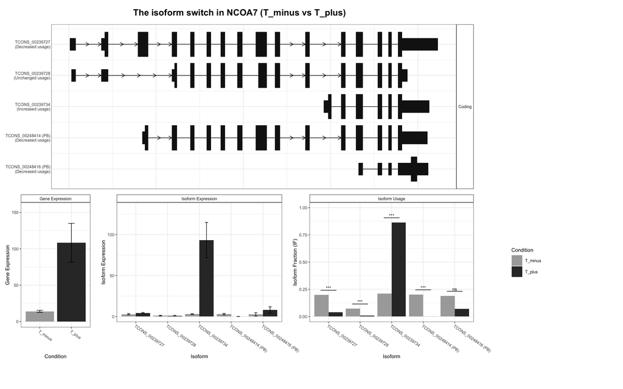

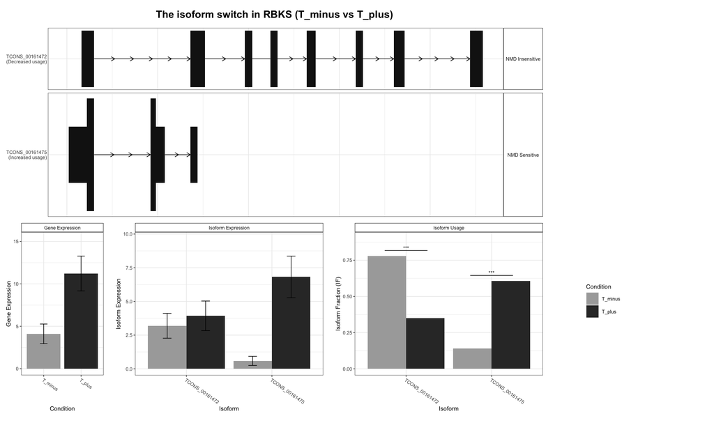

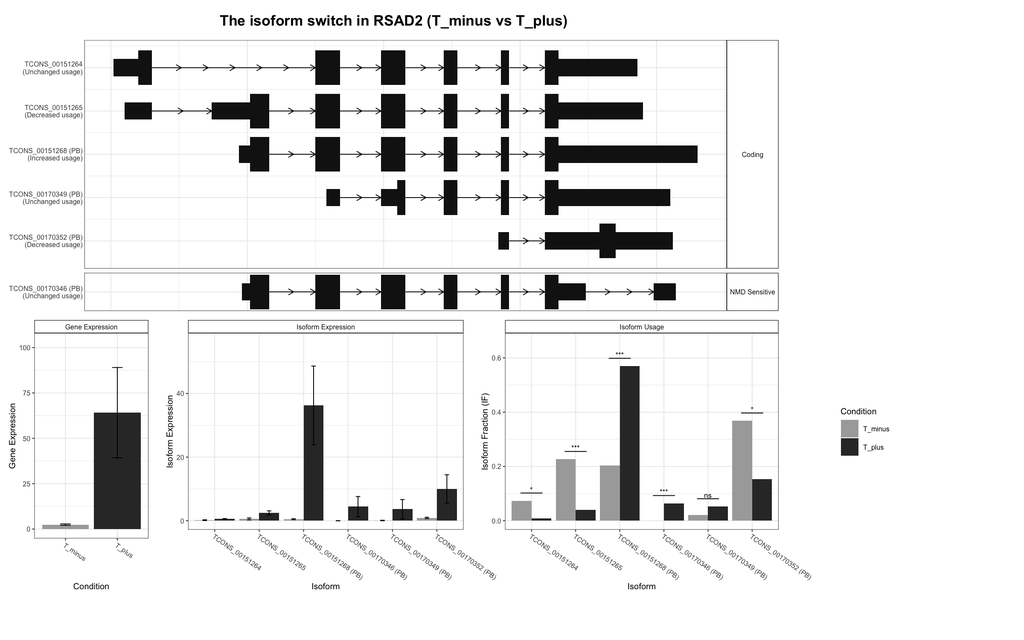

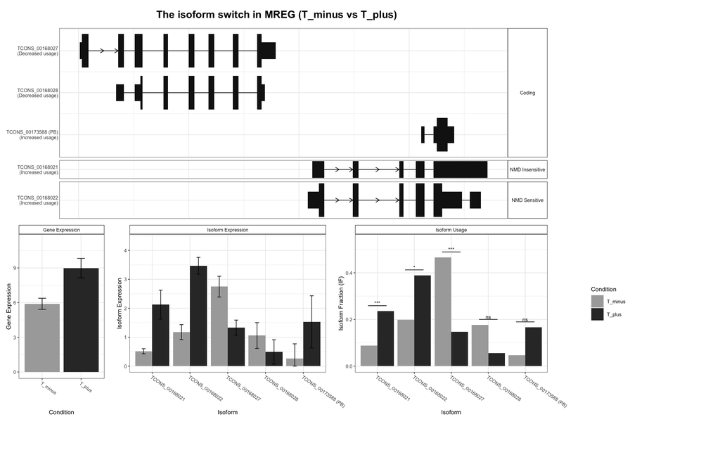

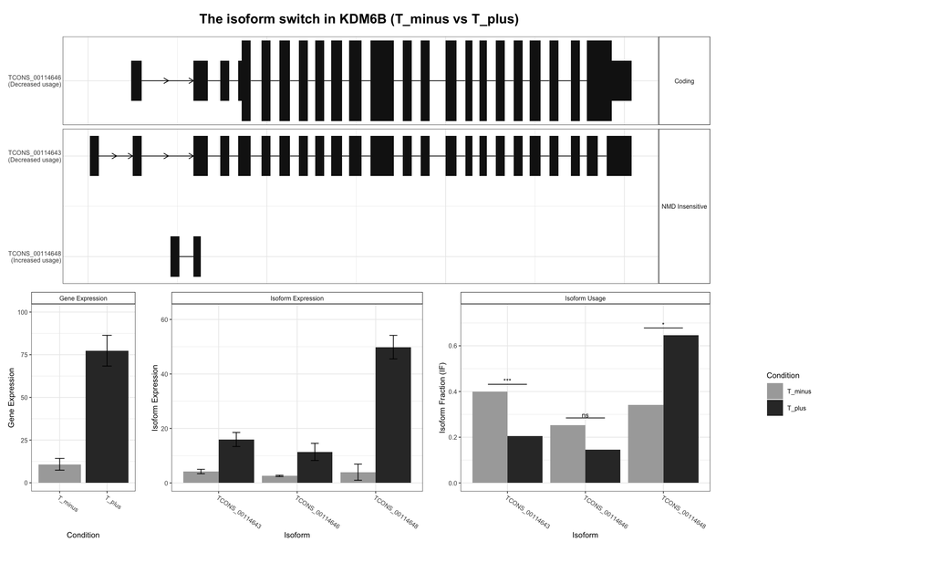

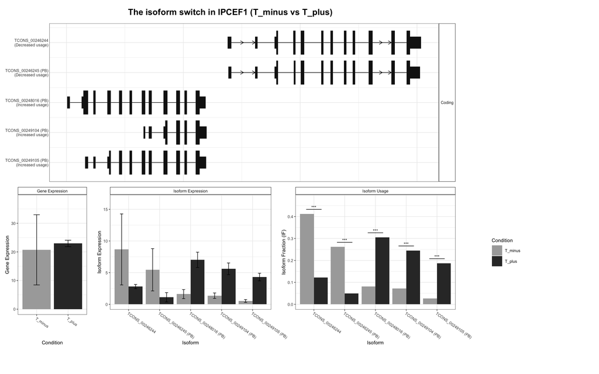

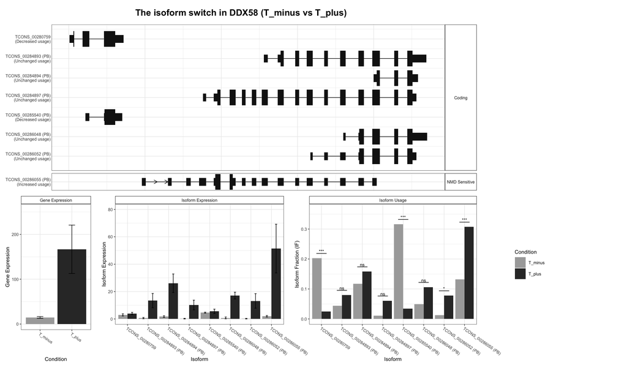

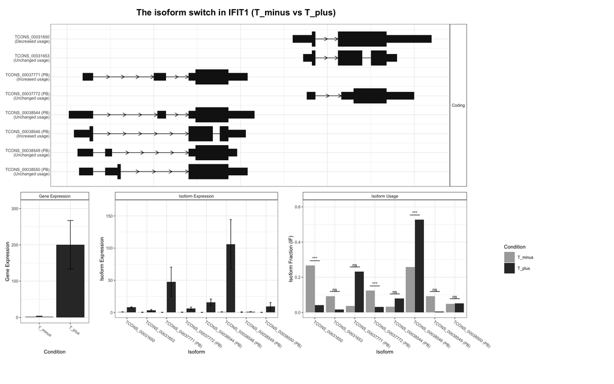

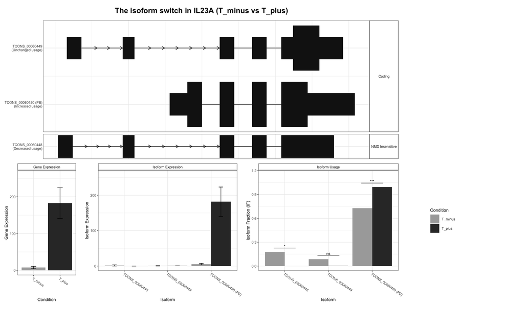

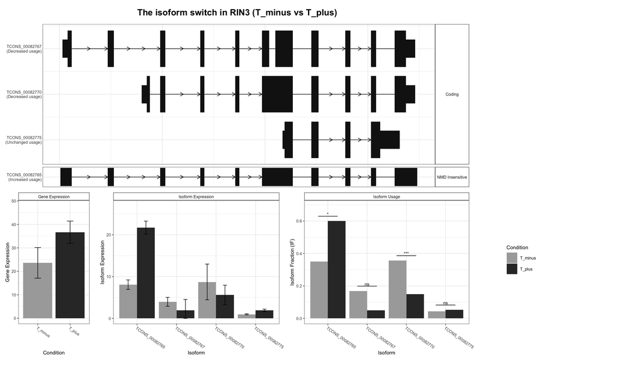

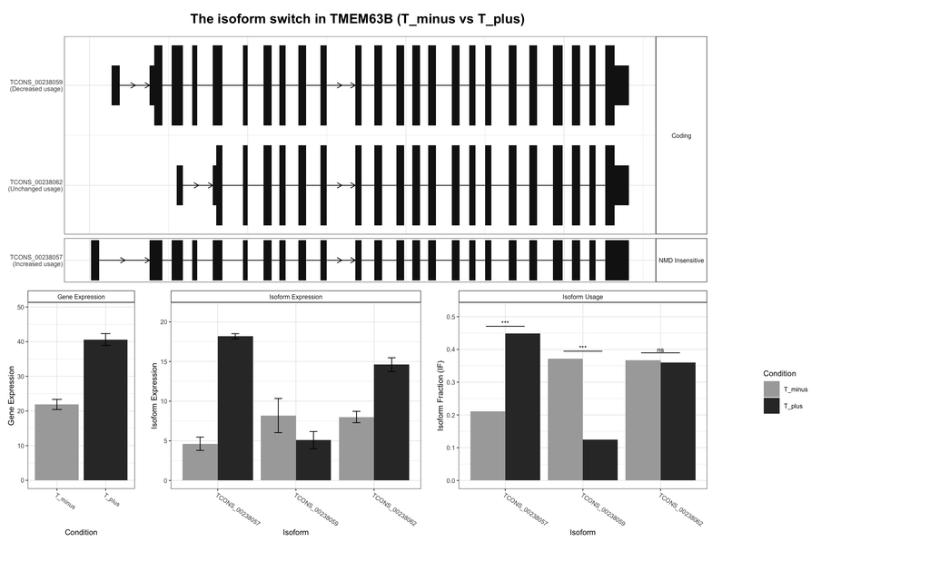

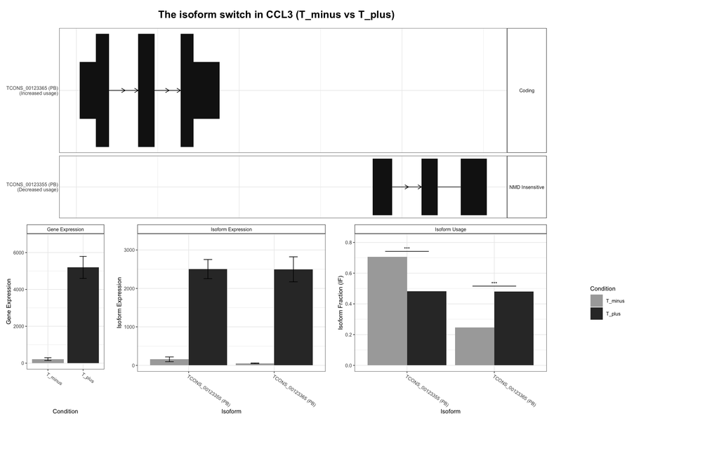

```r
# include_graphics() must be called ONCE on a vector. Looping over files and calling
# it per iteration returns a value that is never printed, which is why this report
# previously rendered with zero images despite 60 switchPlots existing on disk.
t_figs <- sort(list.files(
  fig(),
  pattern = "^switch_plot_T_HT_anchor_rank[0-9]{2}_.*\\.png$",
  full.names = TRUE
))
if (!length(t_figs)) {
  knitr::asis_output("_No T_HT switch plots found._")
} else {
  knitr::include_graphics(utils::head(t_figs, 12))  # first 12 keeps the report navigable
}
```

## 3 H_HT panel

### 3.1 Top 30 genes (ranked by max_abs_dif_switching)

```r
knitr::kable(
  h_top,
  digits = 4,
  caption = "H_HT top 30 genes (q-cutoff filtered; ranked by max_abs_dif_switching)"
)
```

H_HT top 30 genes (q-cutoff filtered; ranked by max_abs_dif_switching)

| gene_id | gene_name | n_isoforms | n_switching_isoforms | n_switching_up | n_switching_down | max_abs_dif_switching | min_isoform_switch_q | min_gene_switch_q | has_opposing_direction_switches | has_multi_isoform_opposing_switch | rank | dataset_key | dataset_label | isoform_q_cutoff | gene_q_cutoff | min_abs_dif_cutoff |
| --- | --- | --- | --- | --- | --- | --- | --- | --- | --- | --- | --- | --- | --- | --- | --- | --- |
| XLOC_045300 | NCOA7 | 14 | 2 | 1 | 1 | 0.5225 | 0.0000 | 0.0000 | TRUE | TRUE | 1 | H_HT | H_HT_supplementary | 0.05 | 0.05 | 0.15 |
| XLOC_001925 | RABGAP1L | 28 | 3 | 1 | 2 | 0.4648 | 0.0000 | 0.0000 | TRUE | TRUE | 2 | H_HT | H_HT_supplementary | 0.05 | 0.05 | 0.15 |
| XLOC_025784 | IER2 | 3 | 2 | 1 | 1 | 0.4389 | 0.0000 | 0.0000 | TRUE | TRUE | 3 | H_HT | H_HT_supplementary | 0.05 | 0.05 | 0.15 |
| XLOC_003522 | DOCK7 | 22 | 2 | 1 | 1 | 0.4147 | 0.0007 | 0.0007 | TRUE | TRUE | 4 | H_HT | H_HT_supplementary | 0.05 | 0.05 | 0.15 |
| XLOC_022602 | SSTR2 | 12 | 2 | 1 | 1 | 0.3909 | 0.0003 | 0.0003 | TRUE | TRUE | 5 | H_HT | H_HT_supplementary | 0.05 | 0.05 | 0.15 |
| XLOC_010685 | RHNO1 | 15 | 2 | 1 | 1 | 0.3792 | 0.0000 | 0.0000 | TRUE | TRUE | 6 | H_HT | H_HT_supplementary | 0.05 | 0.05 | 0.15 |
| XLOC_030435 | PRKD3 | 13 | 2 | 1 | 1 | 0.3787 | 0.0000 | 0.0000 | TRUE | TRUE | 7 | H_HT | H_HT_supplementary | 0.05 | 0.05 | 0.15 |
| XLOC_030175 | CMPK2 | 12 | 2 | 1 | 1 | 0.3369 | 0.0000 | 0.0000 | TRUE | TRUE | 8 | H_HT | H_HT_supplementary | 0.05 | 0.05 | 0.15 |
| XLOC_021883 | TNFAIP1 | 4 | 2 | 1 | 1 | 0.2987 | 0.0004 | 0.0004 | TRUE | TRUE | 9 | H_HT | H_HT_supplementary | 0.05 | 0.05 | 0.15 |
| XLOC_041549 | WDR70 | 7 | 2 | 1 | 1 | 0.2788 | 0.0000 | 0.0000 | TRUE | TRUE | 10 | H_HT | H_HT_supplementary | 0.05 | 0.05 | 0.15 |
| XLOC_026932 | SEMA6B | 4 | 2 | 1 | 1 | 0.2586 | 0.0046 | 0.0046 | TRUE | TRUE | 11 | H_HT | H_HT_supplementary | 0.05 | 0.05 | 0.15 |
| XLOC_043301 | TBCA | 12 | 2 | 1 | 1 | 0.2559 | 0.0001 | 0.0001 | TRUE | TRUE | 12 | H_HT | H_HT_supplementary | 0.05 | 0.05 | 0.15 |
| XLOC_043432 | TTC37 | 29 | 2 | 1 | 1 | 0.2489 | 0.0000 | 0.0000 | TRUE | TRUE | 13 | H_HT | H_HT_supplementary | 0.05 | 0.05 | 0.15 |
| XLOC_052000 | NIPAL2 | 13 | 3 | 1 | 2 | 0.2380 | 0.0000 | 0.0000 | TRUE | TRUE | 14 | H_HT | H_HT_supplementary | 0.05 | 0.05 | 0.15 |
| XLOC_005988 | IFIT2 | 17 | 2 | 1 | 1 | 0.2245 | 0.0000 | 0.0000 | TRUE | TRUE | 15 | H_HT | H_HT_supplementary | 0.05 | 0.05 | 0.15 |
| XLOC_035509 | NDUFA6 | 2 | 2 | 1 | 1 | 0.2227 | 0.0034 | 0.0034 | TRUE | TRUE | 16 | H_HT | H_HT_supplementary | 0.05 | 0.05 | 0.15 |
| XLOC_046825 | HBS1L | 23 | 2 | 1 | 1 | 0.2003 | 0.0000 | 0.0000 | TRUE | TRUE | 17 | H_HT | H_HT_supplementary | 0.05 | 0.05 | 0.15 |
| XLOC_003315 | SLC2A1 | 19 | 2 | 1 | 1 | 0.1921 | 0.0000 | 0.0000 | TRUE | TRUE | 18 | H_HT | H_HT_supplementary | 0.05 | 0.05 | 0.15 |
| XLOC_019531 | SLX1B | 10 | 1 | 1 | 0 | 0.5968 | 0.0013 | 0.0013 | FALSE | FALSE | 19 | H_HT | H_HT_supplementary | 0.05 | 0.05 | 0.15 |
| XLOC_056732 | GPC3 | 6 | 1 | 1 | 0 | 0.5869 | 0.0000 | 0.0000 | FALSE | FALSE | 20 | H_HT | H_HT_supplementary | 0.05 | 0.05 | 0.15 |
| XLOC_013822 | TRIM13 | 10 | 1 | 1 | 0 | 0.4219 | 0.0000 | 0.0000 | FALSE | FALSE | 21 | H_HT | H_HT_supplementary | 0.05 | 0.05 | 0.15 |
| XLOC_018934 | RHCG | 7 | 1 | 0 | 1 | 0.4010 | 0.0144 | 0.0144 | FALSE | FALSE | 22 | H_HT | H_HT_supplementary | 0.05 | 0.05 | 0.15 |
| XLOC_049244 | GTF2IP1 | 10 | 1 | 0 | 1 | 0.3637 | 0.0009 | 0.0009 | FALSE | FALSE | 23 | H_HT | H_HT_supplementary | 0.05 | 0.05 | 0.15 |
| XLOC_007508 | IFITM2 | 30 | 1 | 1 | 0 | 0.3630 | 0.0000 | 0.0000 | FALSE | FALSE | 24 | H_HT | H_HT_supplementary | 0.05 | 0.05 | 0.15 |
| XLOC_044711 | FGD2 | 11 | 1 | 0 | 1 | 0.3599 | 0.0414 | 0.0174 | FALSE | FALSE | 25 | H_HT | H_HT_supplementary | 0.05 | 0.05 | 0.15 |
| XLOC_028473 | MSH6 | 10 | 1 | 1 | 0 | 0.3562 | 0.0000 | 0.0000 | FALSE | FALSE | 26 | H_HT | H_HT_supplementary | 0.05 | 0.05 | 0.15 |
| XLOC_019460 | UBFD1 | 11 | 1 | 0 | 1 | 0.3550 | 0.0000 | 0.0000 | FALSE | FALSE | 27 | H_HT | H_HT_supplementary | 0.05 | 0.05 | 0.15 |
| XLOC_016209 | MBIP | 12 | 1 | 0 | 1 | 0.3144 | 0.0120 | 0.0120 | FALSE | FALSE | 28 | H_HT | H_HT_supplementary | 0.05 | 0.05 | 0.15 |
| XLOC_025640 | SNAPC2 | 6 | 1 | 0 | 1 | 0.3073 | 0.0228 | 0.0228 | FALSE | FALSE | 29 | H_HT | H_HT_supplementary | 0.05 | 0.05 | 0.15 |
| XLOC_047183 | CCZ1 | 11 | 1 | 1 | 0 | 0.3038 | 0.0351 | 0.0351 | FALSE | FALSE | 30 | H_HT | H_HT_supplementary | 0.05 | 0.05 | 0.15 |

### 3.2 H_HT genes with multi-isoform opposing-direction switches

```r
h_interest <- h_top |>
  filter(.data$has_multi_isoform_opposing_switch %in% TRUE) |>
  arrange(desc(.data$max_abs_dif_switching), desc(.data$n_switching_isoforms))
if (nrow(h_interest) == 0) {
  knitr::asis_output("_No H_HT top-30 genes met the multi-isoform opposing-direction criterion._")
} else {
  knitr::kable(
    h_interest,
    digits = 4,
    caption = "H_HT genes of particular interest (>=2 significant isoforms changing in opposing directions)"
  )
}
```

H_HT genes of particular interest (>=2 significant isoforms changing in opposing directions)

| gene_id | gene_name | n_isoforms | n_switching_isoforms | n_switching_up | n_switching_down | max_abs_dif_switching | min_isoform_switch_q | min_gene_switch_q | has_opposing_direction_switches | has_multi_isoform_opposing_switch | rank | dataset_key | dataset_label | isoform_q_cutoff | gene_q_cutoff | min_abs_dif_cutoff |
| --- | --- | --- | --- | --- | --- | --- | --- | --- | --- | --- | --- | --- | --- | --- | --- | --- |
| XLOC_045300 | NCOA7 | 14 | 2 | 1 | 1 | 0.5225 | 0.0000 | 0.0000 | TRUE | TRUE | 1 | H_HT | H_HT_supplementary | 0.05 | 0.05 | 0.15 |
| XLOC_001925 | RABGAP1L | 28 | 3 | 1 | 2 | 0.4648 | 0.0000 | 0.0000 | TRUE | TRUE | 2 | H_HT | H_HT_supplementary | 0.05 | 0.05 | 0.15 |
| XLOC_025784 | IER2 | 3 | 2 | 1 | 1 | 0.4389 | 0.0000 | 0.0000 | TRUE | TRUE | 3 | H_HT | H_HT_supplementary | 0.05 | 0.05 | 0.15 |
| XLOC_003522 | DOCK7 | 22 | 2 | 1 | 1 | 0.4147 | 0.0007 | 0.0007 | TRUE | TRUE | 4 | H_HT | H_HT_supplementary | 0.05 | 0.05 | 0.15 |
| XLOC_022602 | SSTR2 | 12 | 2 | 1 | 1 | 0.3909 | 0.0003 | 0.0003 | TRUE | TRUE | 5 | H_HT | H_HT_supplementary | 0.05 | 0.05 | 0.15 |
| XLOC_010685 | RHNO1 | 15 | 2 | 1 | 1 | 0.3792 | 0.0000 | 0.0000 | TRUE | TRUE | 6 | H_HT | H_HT_supplementary | 0.05 | 0.05 | 0.15 |
| XLOC_030435 | PRKD3 | 13 | 2 | 1 | 1 | 0.3787 | 0.0000 | 0.0000 | TRUE | TRUE | 7 | H_HT | H_HT_supplementary | 0.05 | 0.05 | 0.15 |
| XLOC_030175 | CMPK2 | 12 | 2 | 1 | 1 | 0.3369 | 0.0000 | 0.0000 | TRUE | TRUE | 8 | H_HT | H_HT_supplementary | 0.05 | 0.05 | 0.15 |
| XLOC_021883 | TNFAIP1 | 4 | 2 | 1 | 1 | 0.2987 | 0.0004 | 0.0004 | TRUE | TRUE | 9 | H_HT | H_HT_supplementary | 0.05 | 0.05 | 0.15 |
| XLOC_041549 | WDR70 | 7 | 2 | 1 | 1 | 0.2788 | 0.0000 | 0.0000 | TRUE | TRUE | 10 | H_HT | H_HT_supplementary | 0.05 | 0.05 | 0.15 |
| XLOC_026932 | SEMA6B | 4 | 2 | 1 | 1 | 0.2586 | 0.0046 | 0.0046 | TRUE | TRUE | 11 | H_HT | H_HT_supplementary | 0.05 | 0.05 | 0.15 |
| XLOC_043301 | TBCA | 12 | 2 | 1 | 1 | 0.2559 | 0.0001 | 0.0001 | TRUE | TRUE | 12 | H_HT | H_HT_supplementary | 0.05 | 0.05 | 0.15 |
| XLOC_043432 | TTC37 | 29 | 2 | 1 | 1 | 0.2489 | 0.0000 | 0.0000 | TRUE | TRUE | 13 | H_HT | H_HT_supplementary | 0.05 | 0.05 | 0.15 |
| XLOC_052000 | NIPAL2 | 13 | 3 | 1 | 2 | 0.2380 | 0.0000 | 0.0000 | TRUE | TRUE | 14 | H_HT | H_HT_supplementary | 0.05 | 0.05 | 0.15 |
| XLOC_005988 | IFIT2 | 17 | 2 | 1 | 1 | 0.2245 | 0.0000 | 0.0000 | TRUE | TRUE | 15 | H_HT | H_HT_supplementary | 0.05 | 0.05 | 0.15 |
| XLOC_035509 | NDUFA6 | 2 | 2 | 1 | 1 | 0.2227 | 0.0034 | 0.0034 | TRUE | TRUE | 16 | H_HT | H_HT_supplementary | 0.05 | 0.05 | 0.15 |
| XLOC_046825 | HBS1L | 23 | 2 | 1 | 1 | 0.2003 | 0.0000 | 0.0000 | TRUE | TRUE | 17 | H_HT | H_HT_supplementary | 0.05 | 0.05 | 0.15 |
| XLOC_003315 | SLC2A1 | 19 | 2 | 1 | 1 | 0.1921 | 0.0000 | 0.0000 | TRUE | TRUE | 18 | H_HT | H_HT_supplementary | 0.05 | 0.05 | 0.15 |

### 3.3 H_HT switch plots

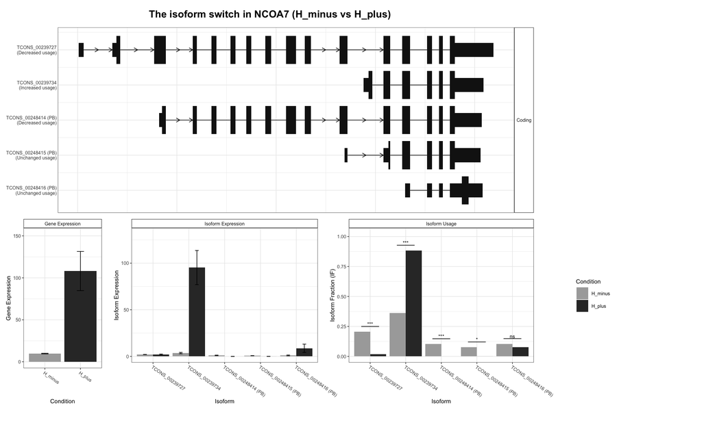

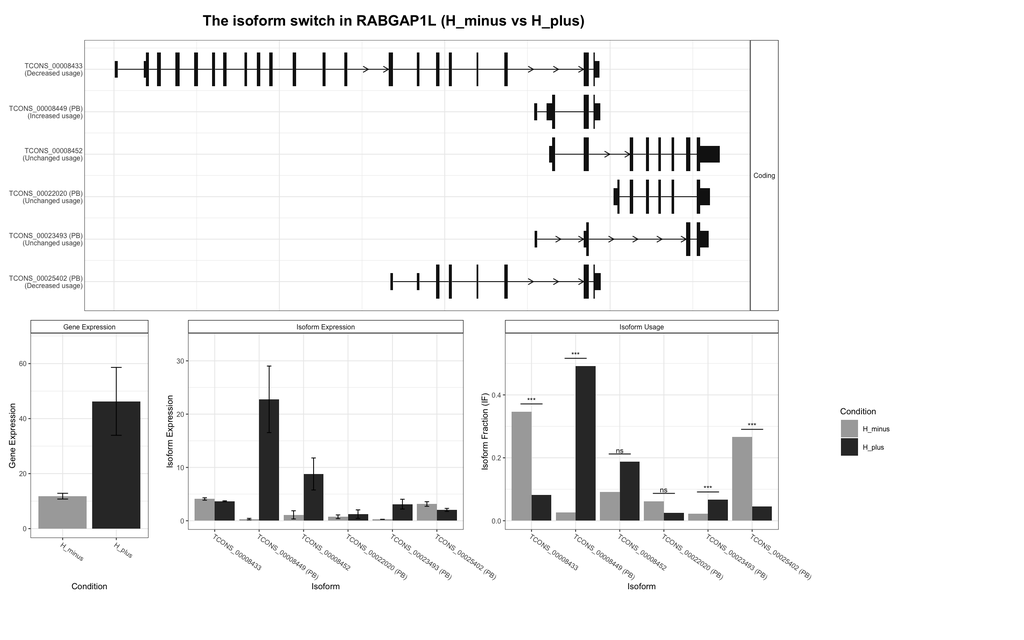

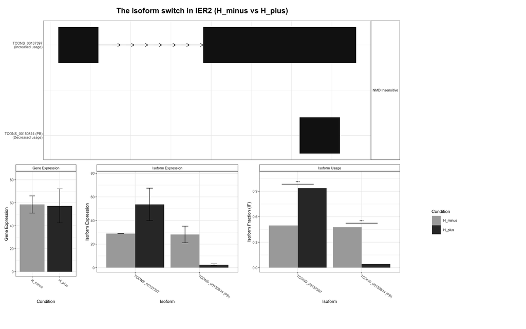

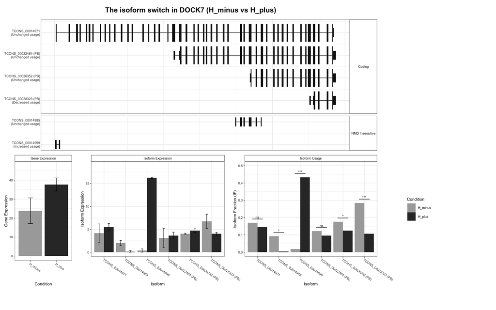

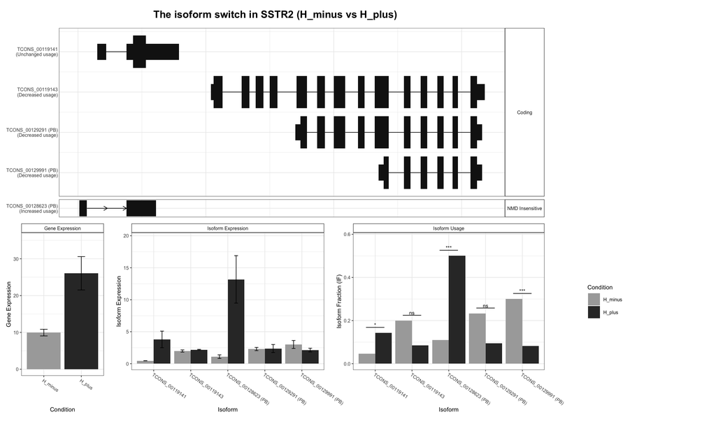

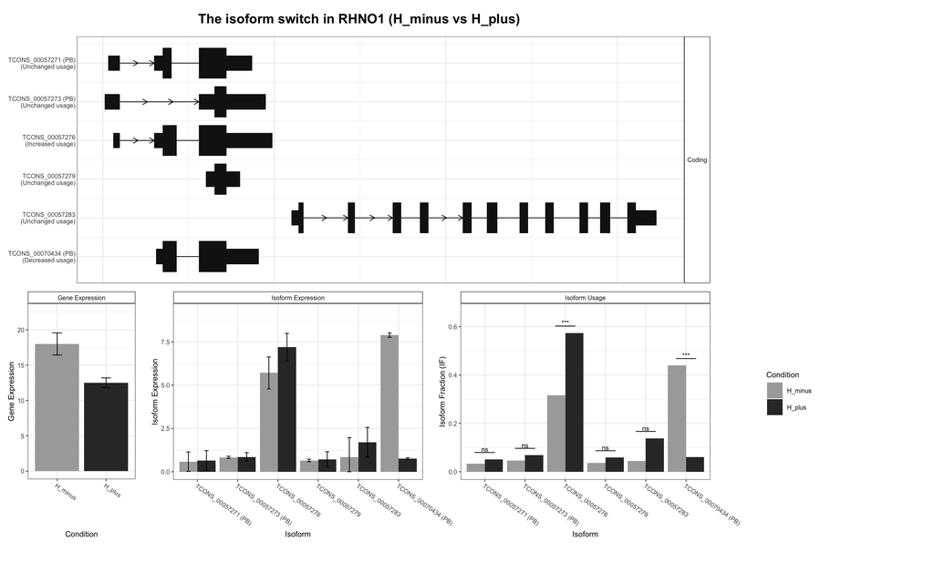

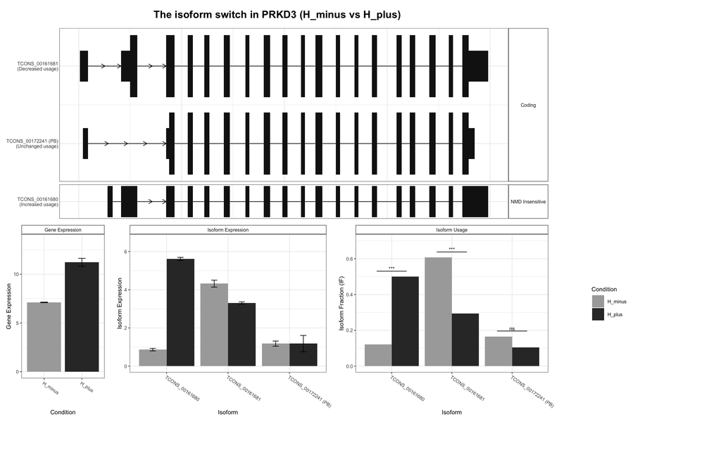

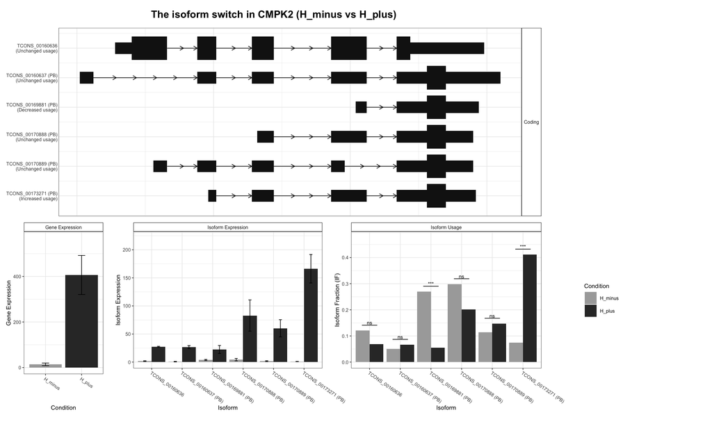

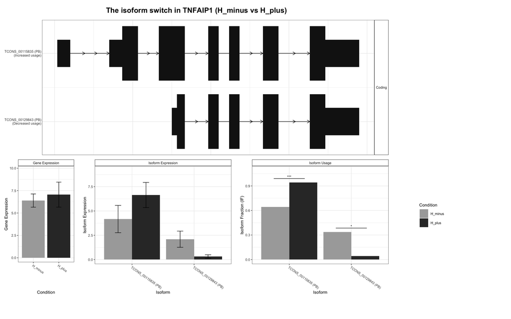

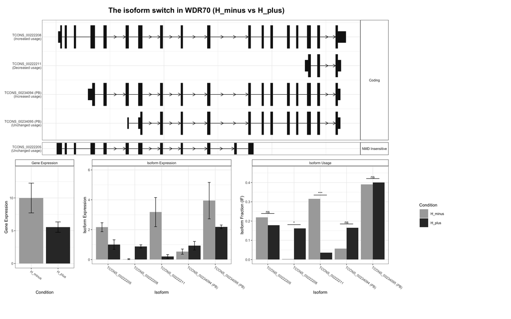

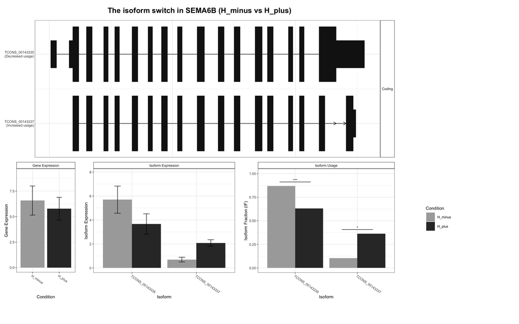

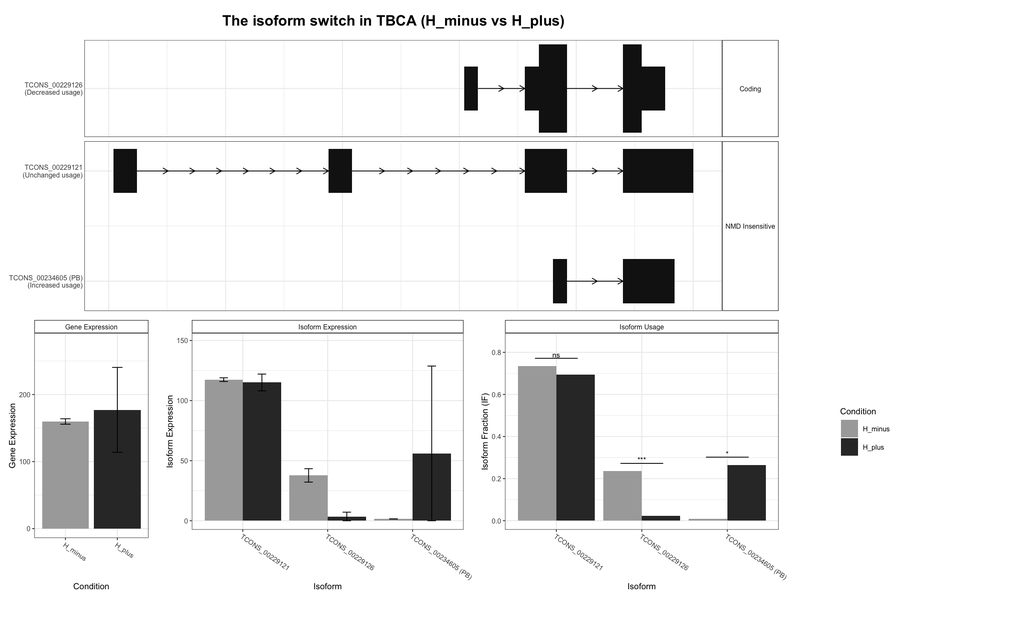

```r
h_figs <- sort(list.files(
  fig(),
  pattern = "^switch_plot_H_HT_supplementary_rank[0-9]{2}_.*\\.png$",
  full.names = TRUE
))
if (!length(h_figs)) {
  knitr::asis_output("_No H_HT switch plots found._")
} else {
  knitr::include_graphics(utils::head(h_figs, 12))
}
```

## 4 T vs H overlap panel

This panel goes beyond “top/significant only” and asks:

- For isoforms significant in `T_HT`, are they also detected in `H_HT`?
- If detected in `H_HT`, are they also significant there?
- If not significant in `H_HT`, what is the observed direction/magnitude context?

### 4.1 Overlap summary

```r
knitr::kable(ov_sum, digits = 4, caption = "Isoform overlap summary: T_HT vs H_HT")
```

Isoform overlap summary: T_HT vs H_HT

| isoform_q_cutoff | gene_q_cutoff | min_abs_dif_cutoff | n_isoforms_T | n_isoforms_H | n_isoforms_shared | n_T_significant | n_H_significant | n_T_significant_present_in_H | n_T_significant_and_H_significant | n_T_significant_present_in_H_same_direction | unfiltered_context_H | unfiltered_context_T | n_genes_tested_in_H | n_T_significant_tested_in_H | n_T_significant_not_detected_in_H | pct_T_significant_also_significant_in_H | pct_T_significant_same_direction_in_H | median_abs_H_dIF_for_T_significant | n_H_significant_tested_in_T | pct_H_significant_also_significant_in_T | pct_H_significant_same_direction_in_T | median_abs_T_dIF_for_H_significant |
| --- | --- | --- | --- | --- | --- | --- | --- | --- | --- | --- | --- | --- | --- | --- | --- | --- | --- | --- | --- | --- | --- | --- |
| 0.05 | 0.05 | 0.15 | 148951 | 128491 | 113695 | 125 | 192 | 105 | 6 | 86 | TRUE | TRUE | 8160 | 105 | 20 | 5.7143 | 81.9048 | 0.0671 | 179 | 3.352 | 64.2458 | 0.0393 |

### 4.2 How often does a T switch reproduce in H?

Replication measured against isoforms actually tested in H

| Significant in T | Tested in H | Not detected in H | % also significant in H | % same direction in H | median \|dIF\| in H |
| --- | --- | --- | --- | --- | --- |
| 125 | 105 | 20 | 5.71 | 81.9 | 0.07 |

**ImportantThe apparent replication rate was an artefact of the reduced object**

Using only what survived `H_HT`’s reduction, 105 of 125 T-significant isoforms appeared in H and 6 of those were also significant — an apparent replication of about 6%. But an isoform only stayed in the reduced object if its gene was already significant there, so that denominator is selected on the outcome.

Against isoforms **actually tested** in H, the rate is **5.7%** (6 of 105). The earlier figure was inflated roughly 1-fold.

### 4.3 Reciprocal: H-significant isoforms in T context

Replication measured against isoforms actually tested in T

| Significant in H | Tested in T | % also significant in T | % same direction in T | median \|dIF\| in T |
| --- | --- | --- | --- | --- |
| 192 | 179 | 3.35 | 64.25 | 0.04 |

### 4.4 Switching co-occurrence against the tested background

Switching in T x switching in H, tested background

| T_switching | H_switching_FALSE | H_switching_TRUE |
| --- | --- | --- |
| FALSE | 7437 | 154 |
| TRUE | 72 | 8 |

### 4.5 T-significant isoforms in H context (including non-significant H)

`H_ctx_dIF` is H’s measured effect from the unfiltered object — available even for isoforms H’s reduced object discarded, which is the point of the context layer.

```r
ov_show <- ov_detail |>
  arrange(desc(abs(.data$T_dIF_n)), .data$T_q_i) |>
  select(
    gene_id, gene_name, isoform_id,
    T_dIF_n, T_q_i, T_significant,
    H_ctx_dIF, H_ctx_q, H_significant,
    same_direction_ctx, overlap_note
  )

knitr::kable(
  utils::head(ov_show, 100),
  digits = 4,
  caption = "Top T-significant isoforms mapped to H context (first 100 rows)"
)
```

Top T-significant isoforms mapped to H context (first 100 rows)

| gene_id | gene_name | isoform_id | T_dIF_n | T_q_i | T_significant | H_ctx_dIF | H_ctx_q | H_significant | same_direction_ctx | overlap_note |
| --- | --- | --- | --- | --- | --- | --- | --- | --- | --- | --- |
| XLOC_045300 | NCOA7 | TCONS_00239734 | 0.6522 | 0.0000 | TRUE | 0.5225 | 0.0000 | TRUE | TRUE | Significant in H |
| XLOC_030370 | RBKS | TCONS_00161475 | 0.4654 | 0.0000 | TRUE | 0.0980 | 0.9974 | FALSE | TRUE | Tested in H, not switching |
| XLOC_030370 | RBKS | TCONS_00161472 | -0.4282 | 0.0000 | TRUE | -0.0889 | 0.9655 | FALSE | TRUE | Tested in H, not switching |
| XLOC_028123 | RSAD2 | TCONS_00151268 | 0.3671 | 0.0000 | TRUE | 0.2059 | 1.0000 | FALSE | TRUE | Tested in H, not switching |
| XLOC_036495 | CD86 | TCONS_00194764 | 0.3443 | 0.0000 | TRUE | 0.0007 | 0.9768 | FALSE | TRUE | Tested in H, not switching |
| XLOC_021587 | KDM6B | TCONS_00114648 | 0.3041 | 0.0281 | TRUE | 0.0633 | 1.0000 | FALSE | TRUE | Tested in H, not switching |
| XLOC_038662 | RUBCN | TCONS_00207289 | -0.2947 | 0.0000 | TRUE | 0.0120 | 1.0000 | FALSE | FALSE | Tested in H, not switching |
| XLOC_013030 | KITLG | TCONS_00068278 | 0.2943 | 0.0017 | TRUE | -0.0282 | 0.8112 | FALSE | FALSE | Tested in H, not switching |
| XLOC_007508 | IFITM2 | TCONS_00039729 | 0.2890 | 0.0000 | TRUE | 0.3630 | 0.0000 | TRUE | TRUE | Significant in H |
| XLOC_053671 | DDX58 | TCONS_00285540 | -0.2820 | 0.0000 | TRUE | -0.0853 | 0.0042 | FALSE | TRUE | Tested in H, not switching |
| XLOC_005992 | IFIT1 | TCONS_00038546 | 0.2691 | 0.0000 | TRUE | 0.1323 | 0.8965 | FALSE | TRUE | Tested in H, not switching |
| XLOC_003170 | TMEM234 | TCONS_00013260 | -0.2684 | 0.0026 | TRUE | -0.2981 | 0.0432 | TRUE | TRUE | Significant in H |
| XLOC_007960 | ALKBH3 | TCONS_00041705 | 0.2671 | 0.0000 | TRUE | 0.5350 | 0.5179 | FALSE | TRUE | Tested in H, not switching |
| XLOC_011323 | IL23A | TCONS_00060450 | 0.2664 | 0.0000 | TRUE | 0.2161 | 0.8881 | FALSE | TRUE | Tested in H, not switching |
| XLOC_033510 | RGS19 | TCONS_00179445 | 0.2625 | 0.0000 | TRUE | 0.1299 | 1.0000 | FALSE | TRUE | Tested in H, not switching |
| XLOC_046278 | PLA2G7 | TCONS_00247239 | -0.2557 | 0.0167 | TRUE | 0.0023 | 1.0000 | FALSE | FALSE | Tested in H, not switching |
| XLOC_004716 | PHLDA3 | TCONS_00019593 | 0.2511 | 0.0000 | TRUE | 0.0581 | 1.0000 | FALSE | TRUE | Tested in H, not switching |
| XLOC_015708 | RIN3 | TCONS_00082765 | 0.2494 | 0.0265 | TRUE | 0.0854 | 1.0000 | FALSE | TRUE | Tested in H, not switching |
| XLOC_044803 | TMEM63B | TCONS_00238059 | -0.2477 | 0.0000 | TRUE | -0.1325 | 0.7070 | FALSE | TRUE | Tested in H, not switching |
| XLOC_042338 | ARHGAP26 | TCONS_00225601 | -0.2469 | 0.0003 | TRUE | -0.0948 | 1.0000 | FALSE | TRUE | Tested in H, not switching |
| XLOC_019483 | LCMT1 | TCONS_00112926 | -0.2423 | 0.0003 | TRUE | -0.0055 | 1.0000 | FALSE | TRUE | Tested in H, not switching |
| XLOC_003699 | GBP1 | TCONS_00015616 | -0.2393 | 0.0072 | TRUE | -0.1208 | 0.7972 | FALSE | TRUE | Tested in H, not switching |
| XLOC_044803 | TMEM63B | TCONS_00238057 | 0.2368 | 0.0000 | TRUE | 0.1489 | 0.6026 | FALSE | TRUE | Tested in H, not switching |
| XLOC_023406 | CCL3 | TCONS_00123365 | 0.2347 | 0.0000 | TRUE | 0.1360 | 0.9798 | FALSE | TRUE | Tested in H, not switching |
| XLOC_034711 | CCDC117 | TCONS_00189711 | -0.2333 | 0.0390 | TRUE | 0.0655 | 1.0000 | FALSE | FALSE | Tested in H, not switching |
| XLOC_005992 | IFIT1 | TCONS_00031650 | -0.2257 | 0.0000 | TRUE | -0.0694 | 0.0000 | FALSE | TRUE | Tested in H, not switching |
| XLOC_021196 | COG4 | TCONS_00110973 | -0.2253 | 0.0000 | TRUE | -0.0778 | 1.0000 | FALSE | TRUE | Tested in H, not switching |
| XLOC_023406 | CCL3 | TCONS_00123355 | -0.2242 | 0.0000 | TRUE | -0.1310 | 1.0000 | FALSE | TRUE | Tested in H, not switching |
| XLOC_046969 | IPCEF1 | TCONS_00248016 | 0.2238 | 0.0000 | TRUE | -0.0644 | 1.0000 | FALSE | FALSE | Tested in H, not switching |
| XLOC_037565 | RASSF1 | TCONS_00200674 | 0.2230 | 0.0323 | TRUE | 0.2064 | 0.8870 | FALSE | TRUE | Tested in H, not switching |

[output cut: 70 more lines]